# Binary classification problem

### Project Objective

The goal of this project was to build a predictive model to determine which passengers were more likely to survive the Titanic disaster, based on passenger data such as name, age, gender, and socio-economic class.

```python
import pandas as pd
import numpy as np
import seaborn as sns
import matplotlib.pyplot as plt
from sklearn.ensemble import RandomForestClassifier
from sklearn.linear_model import LogisticRegression
from sklearn.metrics import classification_report, confusion_matrix
from sklearn.metrics import accuracy_score, f1_score, confusion_matrix, classification_report
import pandas as pd
import matplotlib.pyplot as plt
import seaborn as sns
from sklearn.svm import SVC
from sklearn.ensemble import RandomForestClassifier, GradientBoostingClassifier, AdaBoostClassifier
from sklearn.neighbors import KNeighborsClassifier
from sklearn.model_selection import GridSearchCV
```

```python
df = pd.read_excel('titanic3.xls')
```

```python
df.head()
```

|  | pclass | survived | name | sex | age | sibsp | parch | ticket | fare | cabin | embarked | boat | body | home.dest |
| --- | --- | --- | --- | --- | --- | --- | --- | --- | --- | --- | --- | --- | --- | --- |
| 0 | 1 | 1 | Allen, Miss. Elisabeth Walton | female | 29.0000 | 0 | 0 | 24160 | 211.3375 | B5 | S | 2 | NaN | St Louis, MO |
| 1 | 1 | 1 | Allison, Master. Hudson Trevor | male | 0.9167 | 1 | 2 | 113781 | 151.5500 | C22 C26 | S | 11 | NaN | Montreal, PQ / Chesterville, ON |
| 2 | 1 | 0 | Allison, Miss. Helen Loraine | female | 2.0000 | 1 | 2 | 113781 | 151.5500 | C22 C26 | S | NaN | NaN | Montreal, PQ / Chesterville, ON |
| 3 | 1 | 0 | Allison, Mr. Hudson Joshua Creighton | male | 30.0000 | 1 | 2 | 113781 | 151.5500 | C22 C26 | S | NaN | 135.0 | Montreal, PQ / Chesterville, ON |
| 4 | 1 | 0 | Allison, Mrs. Hudson J C (Bessie Waldo Daniels) | female | 25.0000 | 1 | 2 | 113781 | 151.5500 | C22 C26 | S | NaN | NaN | Montreal, PQ / Chesterville, ON |

```python
df.tail()
```

|  | pclass | survived | name | sex | age | sibsp | parch | ticket | fare | cabin | embarked | boat | body | home.dest |
| --- | --- | --- | --- | --- | --- | --- | --- | --- | --- | --- | --- | --- | --- | --- |
| 1304 | 3 | 0 | Zabour, Miss. Hileni | female | 14.5 | 1 | 0 | 2665 | 14.4542 | NaN | C | NaN | 328.0 | NaN |
| 1305 | 3 | 0 | Zabour, Miss. Thamine | female | NaN | 1 | 0 | 2665 | 14.4542 | NaN | C | NaN | NaN | NaN |
| 1306 | 3 | 0 | Zakarian, Mr. Mapriededer | male | 26.5 | 0 | 0 | 2656 | 7.2250 | NaN | C | NaN | 304.0 | NaN |
| 1307 | 3 | 0 | Zakarian, Mr. Ortin | male | 27.0 | 0 | 0 | 2670 | 7.2250 | NaN | C | NaN | NaN | NaN |
| 1308 | 3 | 0 | Zimmerman, Mr. Leo | male | 29.0 | 0 | 0 | 315082 | 7.8750 | NaN | S | NaN | NaN | NaN |

```python
df.info()
```

```
<class 'pandas.core.frame.DataFrame'>
RangeIndex: 1309 entries, 0 to 1308
Data columns (total 14 columns):
 #   Column     Non-Null Count  Dtype
---  ------     --------------  -----
 0   pclass     1309 non-null   int64
 1   survived   1309 non-null   int64
 2   name       1309 non-null   object
 3   sex        1309 non-null   object
 4   age        1046 non-null   float64
 5   sibsp      1309 non-null   int64
 6   parch      1309 non-null   int64
 7   ticket     1309 non-null   object
 8   fare       1308 non-null   float64
 9   cabin      295 non-null    object
 10  embarked   1307 non-null   object
 11  boat       486 non-null    object
 12  body       121 non-null    float64
 13  home.dest  745 non-null    object
dtypes: float64(3), int64(4), object(7)
memory usage: 143.3+ KB
```

This dataset is commonly used for classification problems, where the goal is to predict whether a passenger survived based on other features.

```python
df.columns
```

```
Index(['pclass', 'survived', 'name', 'sex', 'age', 'sibsp', 'parch', 'ticket',
       'fare', 'cabin', 'embarked', 'boat', 'body', 'home.dest'],
      dtype='object')
```

```python
df.describe()
```

|  | pclass | survived | age | sibsp | parch | fare | body |
| --- | --- | --- | --- | --- | --- | --- | --- |
| count | 1309.000000 | 1309.000000 | 1046.000000 | 1309.000000 | 1309.000000 | 1308.000000 | 121.000000 |
| mean | 2.294882 | 0.381971 | 29.881135 | 0.498854 | 0.385027 | 33.295479 | 160.809917 |
| std | 0.837836 | 0.486055 | 14.413500 | 1.041658 | 0.865560 | 51.758668 | 97.696922 |
| min | 1.000000 | 0.000000 | 0.166700 | 0.000000 | 0.000000 | 0.000000 | 1.000000 |
| 25% | 2.000000 | 0.000000 | 21.000000 | 0.000000 | 0.000000 | 7.895800 | 72.000000 |
| 50% | 3.000000 | 0.000000 | 28.000000 | 0.000000 | 0.000000 | 14.454200 | 155.000000 |
| 75% | 3.000000 | 1.000000 | 39.000000 | 1.000000 | 0.000000 | 31.275000 | 256.000000 |
| max | 3.000000 | 1.000000 | 80.000000 | 8.000000 | 9.000000 | 512.329200 | 328.000000 |

the target variable is survived, where:

1 indicates the passenger survived.

0 indicates the passenger did not survive.

```python
df.isnull().sum()
```

```
pclass          0
survived        0
name            0
sex             0
age           263
sibsp           0
parch           0
ticket          0
fare            1
cabin        1014
embarked        2
boat          823
body         1188
home.dest     564
dtype: int64
```

```python
df.duplicated().sum()
```

```
0
```

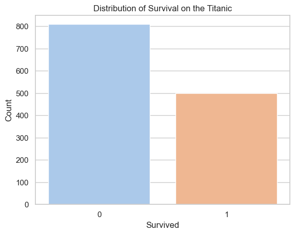

```python
# Set the aesthetic style of the plots
sns.set(style="whitegrid")

# Count the number of occurrences for each class (survived or not)
sns.countplot(x='survived', data=df, palette='pastel')

# Add labels and title to the plot
plt.title('Distribution of Survival on the Titanic')
plt.xlabel('Survived')
plt.ylabel('Count')

# Display the plot
plt.show()
```

```python
# Count the number of occurrences for each class (survived or not)
survival_counts = df['survived'].value_counts()

# Print the counts
print(survival_counts)
```

```
survived
0    809
1    500
Name: count, dtype: int64
```

# Data Preprocessing

Fill missing values

```python
# Fill missing values in 'age' with the median
df['age'].fillna(df['age'].median(), inplace=True)

# Fill missing values in 'embarked' with the mode
df['embarked'].fillna(df['embarked'].mode()[0], inplace=True)

# Drop 'cabin' due to a large number of missing values
df.drop(columns=['cabin'], inplace=True)

# Drop columns like 'boat', 'body', and 'home.dest' as they may not contribute meaningfully to survival prediction
df.drop(columns=['boat', 'body', 'home.dest'], inplace=True)
```

```python
df.isnull().sum()
```

```
pclass      0
survived    0
name        0
sex         0
age         0
sibsp       0
parch       0
ticket      0
fare        1
embarked    0
dtype: int64
```

```python
# Fill the missing value in 'fare' with the median
df['fare'].fillna(df['fare'].median(), inplace=True)
```

```python
df.isnull().sum()
```

```
pclass      0
survived    0
name        0
sex         0
age         0
sibsp       0
parch       0
ticket      0
fare        0
embarked    0
dtype: int64
```

```python
df.head()
```

|  | pclass | survived | name | sex | age | sibsp | parch | ticket | fare | embarked |
| --- | --- | --- | --- | --- | --- | --- | --- | --- | --- | --- |
| 0 | 1 | 1 | Allen, Miss. Elisabeth Walton | female | 29.0000 | 0 | 0 | 24160 | 211.3375 | S |
| 1 | 1 | 1 | Allison, Master. Hudson Trevor | male | 0.9167 | 1 | 2 | 113781 | 151.5500 | S |
| 2 | 1 | 0 | Allison, Miss. Helen Loraine | female | 2.0000 | 1 | 2 | 113781 | 151.5500 | S |
| 3 | 1 | 0 | Allison, Mr. Hudson Joshua Creighton | male | 30.0000 | 1 | 2 | 113781 | 151.5500 | S |
| 4 | 1 | 0 | Allison, Mrs. Hudson J C (Bessie Waldo Daniels) | female | 25.0000 | 1 | 2 | 113781 | 151.5500 | S |

Handle Categorical Variables:

You can convert categorical variables like sex and embarked into numeric form using one-hot encoding.

```python
# Convert 'sex' into numeric (0 for male, 1 for female)
df['sex'] = df['sex'].map({'male': 0, 'female': 1})

# One-hot encode 'embarked'
df = pd.get_dummies(df, columns=['embarked'], drop_first=True)
```

```python
df.head()
```

|  | pclass | survived | name | sex | age | sibsp | parch | ticket | fare | embarked_Q | embarked_S |
| --- | --- | --- | --- | --- | --- | --- | --- | --- | --- | --- | --- |
| 0 | 1 | 1 | Allen, Miss. Elisabeth Walton | 1 | 29.0000 | 0 | 0 | 24160 | 211.3375 | False | True |
| 1 | 1 | 1 | Allison, Master. Hudson Trevor | 0 | 0.9167 | 1 | 2 | 113781 | 151.5500 | False | True |
| 2 | 1 | 0 | Allison, Miss. Helen Loraine | 1 | 2.0000 | 1 | 2 | 113781 | 151.5500 | False | True |
| 3 | 1 | 0 | Allison, Mr. Hudson Joshua Creighton | 0 | 30.0000 | 1 | 2 | 113781 | 151.5500 | False | True |
| 4 | 1 | 0 | Allison, Mrs. Hudson J C (Bessie Waldo Daniels) | 1 | 25.0000 | 1 | 2 | 113781 | 151.5500 | False | True |

Columns:

1. sibsp: Number of siblings or spouses aboard the Titanic. This indicates how many family members a passenger had with them on the ship.
2. parch: Number of parents or children aboard the Titanic. This shows how many direct family members (parents or children) a passenger had with them.

Feature Engineering:

Create or modify features to add more information to your model.

```python
# Create a 'family_size' feature
df['family_size'] = df['sibsp'] + df['parch']

# Drop the 'name' and 'ticket' columns as they are unlikely to be useful in modeling
df.drop(columns=['name', 'ticket'], inplace=True)
```

```python
df.head()
```

|  | pclass | survived | sex | age | sibsp | parch | fare | embarked_Q | embarked_S | family_size |
| --- | --- | --- | --- | --- | --- | --- | --- | --- | --- | --- |
| 0 | 1 | 1 | 1 | 29.0000 | 0 | 0 | 211.3375 | False | True | 0 |
| 1 | 1 | 1 | 0 | 0.9167 | 1 | 2 | 151.5500 | False | True | 3 |
| 2 | 1 | 0 | 1 | 2.0000 | 1 | 2 | 151.5500 | False | True | 3 |
| 3 | 1 | 0 | 0 | 30.0000 | 1 | 2 | 151.5500 | False | True | 3 |
| 4 | 1 | 0 | 1 | 25.0000 | 1 | 2 | 151.5500 | False | True | 3 |

Normalize or Standardize Data:

Standardize the age and fare columns to have a mean of 0 and a standard deviation of 1.

Standardizing your data ensures that all features are on a similar scale, which can lead to more stable and faster learning for many machine learning algorithms.

```python
from sklearn.preprocessing import StandardScaler

scaler = StandardScaler()
df[['age', 'fare']] = scaler.fit_transform(df[['age', 'fare']])
```

```python
df.head()
```

|  | pclass | survived | sex | age | sibsp | parch | fare | embarked_Q | embarked_S | family_size |
| --- | --- | --- | --- | --- | --- | --- | --- | --- | --- | --- |
| 0 | 1 | 1 | 1 | -0.039005 | 0 | 0 | 3.442584 | False | True | 0 |
| 1 | 1 | 1 | 0 | -2.215952 | 1 | 2 | 2.286639 | False | True | 3 |
| 2 | 1 | 0 | 1 | -2.131977 | 1 | 2 | 2.286639 | False | True | 3 |
| 3 | 1 | 0 | 0 | 0.038512 | 1 | 2 | 2.286639 | False | True | 3 |
| 4 | 1 | 0 | 1 | -0.349075 | 1 | 2 | 2.286639 | False | True | 3 |

Split Data:

Finally, split the data into training and testing sets.

```python
from sklearn.model_selection import train_test_split

X = df.drop('survived', axis=1)
y = df['survived']

X_train, X_test, y_train, y_test = train_test_split(X, y, test_size=0.2, random_state=42)
```

Balance the Data

Apply SMOTE to balance the training data.

```python
from imblearn.over_sampling import SMOTE

# Initialize SMOTE
smote = SMOTE(random_state=42)

# Apply SMOTE to the training data
X_train_resampled, y_train_resampled = smote.fit_resample(X_train, y_train)
```

Before SMOTE

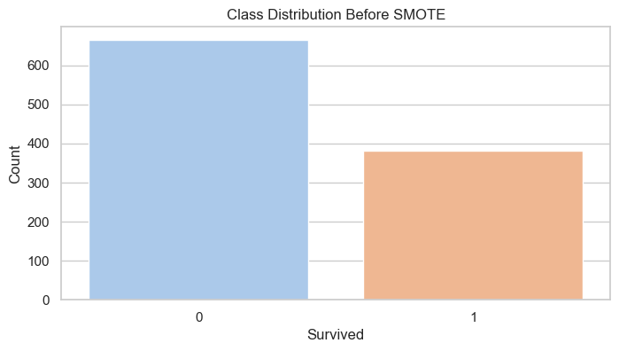

```python
import seaborn as sns
import matplotlib.pyplot as plt

# Plot the class distribution before SMOTE
plt.figure(figsize=(8, 4))
sns.countplot(x=y_train, palette='pastel')
plt.title('Class Distribution Before SMOTE')
plt.xlabel('Survived')
plt.ylabel('Count')
plt.show()
```

After SMOTE

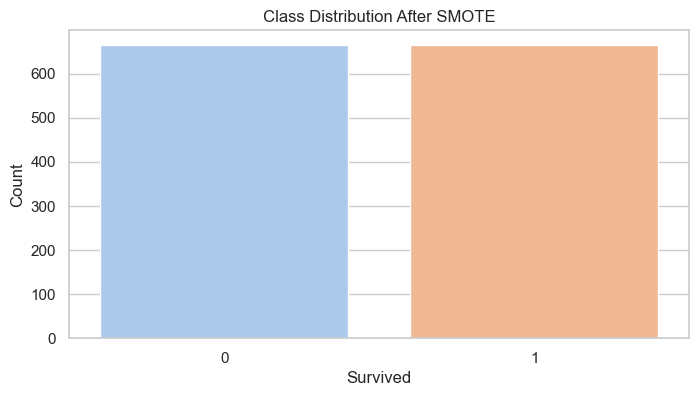

```python
# Plot the class distribution after SMOTE
plt.figure(figsize=(8, 4))
sns.countplot(x=y_train_resampled, palette='pastel')
plt.title('Class Distribution After SMOTE')
plt.xlabel('Survived')
plt.ylabel('Count')
plt.show()
```

```python
# Print the class distribution after SMOTE
print("Class distribution after SMOTE:")
print(pd.Series(y_train_resampled).value_counts())
```

```
Class distribution after SMOTE:
survived
0    665
1    665
Name: count, dtype: int64
```

# EDA

Age Distribution

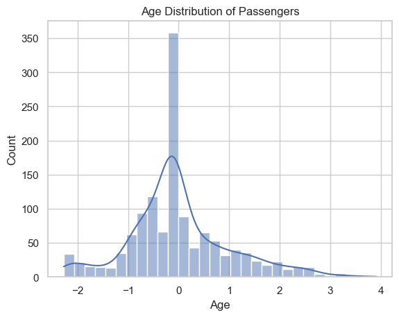

```python
sns.histplot(df['age'].dropna(), kde=True, bins=30)
plt.title('Age Distribution of Passengers')
plt.xlabel('Age')
plt.ylabel('Count')
plt.show()
```

Analyze Survival Rates

Examine how survival rates vary with different features.

Survival by Gender

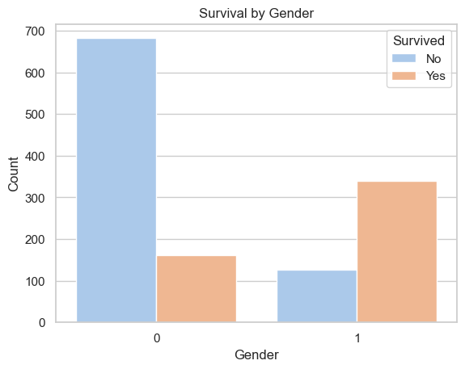

```python
sns.countplot(x='sex', hue='survived', data=df, palette='pastel')
plt.title('Survival by Gender')
plt.xlabel('Gender')
plt.ylabel('Count')
plt.legend(title='Survived', labels=['No', 'Yes'])
plt.show()
```

Survival by Passenger Class

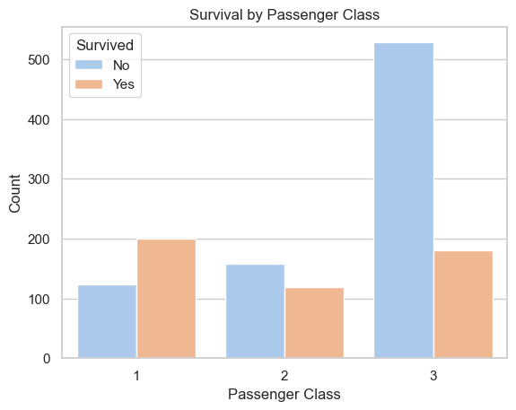

```python
sns.countplot(x='pclass', hue='survived', data=df, palette='pastel')
plt.title('Survival by Passenger Class')
plt.xlabel('Passenger Class')
plt.ylabel('Count')
plt.legend(title='Survived', labels=['No', 'Yes'])
plt.show()
```

Correlation Analysis

Check how features are correlated with survival and with each other.

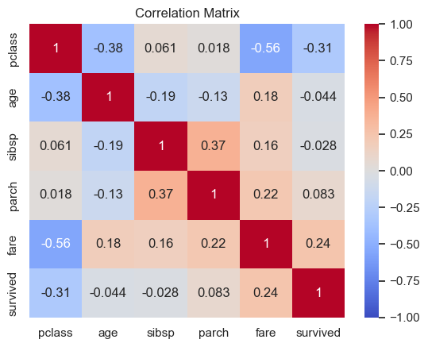

```python
# Calculate correlation matrix
correlation_matrix = df[['pclass', 'age', 'sibsp', 'parch', 'fare', 'survived']].corr()

# Plot heatmap
sns.heatmap(correlation_matrix, annot=True, cmap='coolwarm', vmin=-1, vmax=1)
plt.title('Correlation Matrix')
plt.show()
```

# Model Training

Logistic Regression:

```python
# Initialize and train the model
lr = LogisticRegression(random_state=42)
lr.fit(X_train_resampled, y_train_resampled)

# Predict on the test set
y_pred_lr = lr.predict(X_test)

# Evaluate the model
print("Logistic Regression Performance:")
print(confusion_matrix(y_test, y_pred_lr))
print(classification_report(y_test, y_pred_lr))
```

```
Logistic Regression Performance:
[[119  25]
 [ 35  83]]
              precision    recall  f1-score   support

           0       0.77      0.83      0.80       144
           1       0.77      0.70      0.73       118

    accuracy                           0.77       262
   macro avg       0.77      0.76      0.77       262
weighted avg       0.77      0.77      0.77       262
```

Random Forest Classifier:

```python
# Initialize and train the model
rf = RandomForestClassifier(random_state=42)
rf.fit(X_train_resampled, y_train_resampled)

# Predict on the test set
y_pred_rf = rf.predict(X_test)

# Evaluate the model
print("Random Forest Performance:")
print(confusion_matrix(y_test, y_pred_rf))
print(classification_report(y_test, y_pred_rf))
```

```
Random Forest Performance:
[[123  21]
 [ 32  86]]
              precision    recall  f1-score   support

           0       0.79      0.85      0.82       144
           1       0.80      0.73      0.76       118

    accuracy                           0.80       262
   macro avg       0.80      0.79      0.79       262
weighted avg       0.80      0.80      0.80       262
```

evaluate and compare the models:

```python
from sklearn.metrics import accuracy_score, f1_score

# Logistic Regression Evaluation
accuracy_lr = accuracy_score(y_test, y_pred_lr)
f1_lr = f1_score(y_test, y_pred_lr)

print(f"Logistic Regression Accuracy: {accuracy_lr:.2f}")
print(f"Logistic Regression F1 Score: {f1_lr:.2f}")

# Random Forest Evaluation
accuracy_rf = accuracy_score(y_test, y_pred_rf)
f1_rf = f1_score(y_test, y_pred_rf)

print(f"Random Forest Accuracy: {accuracy_rf:.2f}")
print(f"Random Forest F1 Score: {f1_rf:.2f}")
```

```
Logistic Regression Accuracy: 0.77
Logistic Regression F1 Score: 0.73
Random Forest Accuracy: 0.80
Random Forest F1 Score: 0.76
```

NOTES:

1. For imbalanced datasets, accuracy can be misleading. In such cases, F1 Score, Precision, Recall, or ROC-AUC are preferred.
2. If false positives and false negatives have different costs, use Precision and Recall.
3. For a general view of model performance, ROC-AUC provides insight into how well the model differentiates between classes across various thresholds.
4. Use F1 Score when you need a balance between precision and recall, especially with imbalanced data.

Key Points:

1. Recall (Sensitivity):

What It Measures: How well the model finds all the positive cases. When Important: When missing a positive case is bad (e.g., diagnosing a disease). You want to catch every possible positive, even if it means some false positives.

1. Precision:

What It Measures: How accurate the model’s positive predictions are. When Important: When false positives are costly or problematic (e.g., spam filtering). You want to make sure that the positives predicted by the model are actually positive.

Simple Guidelines:

1. If Missing a Positive Case is Costly (e.g., Disease Detection): Focus on Recall. You want to catch every positive case, even if it means getting some false alarms.
2. If False Positives are Costly (e.g., Spam Detection): Focus on Precision. You want to make sure that what the model predicts as positive is actually positive.

Support Vector Machine (SVM)

```python
from sklearn.svm import SVC

# Initialize and train the model
svc = SVC(random_state=42)
svc.fit(X_train_resampled, y_train_resampled)

# Predict on the test set
y_pred_svc = svc.predict(X_test)

# Evaluate the model
print("SVM Performance:")
print(confusion_matrix(y_test, y_pred_svc))
print(classification_report(y_test, y_pred_svc))
```

```
SVM Performance:
[[125  19]
 [ 37  81]]
              precision    recall  f1-score   support

           0       0.77      0.87      0.82       144
           1       0.81      0.69      0.74       118

    accuracy                           0.79       262
   macro avg       0.79      0.78      0.78       262
weighted avg       0.79      0.79      0.78       262
```

Gradient Boosting Classifier

```python
from sklearn.ensemble import GradientBoostingClassifier

# Initialize and train the model
gb = GradientBoostingClassifier(random_state=42)
gb.fit(X_train_resampled, y_train_resampled)

# Predict on the test set
y_pred_gb = gb.predict(X_test)

# Evaluate the model
print("Gradient Boosting Performance:")
print(confusion_matrix(y_test, y_pred_gb))
print(classification_report(y_test, y_pred_gb))
```

```
Gradient Boosting Performance:
[[129  15]
 [ 38  80]]
              precision    recall  f1-score   support

           0       0.77      0.90      0.83       144
           1       0.84      0.68      0.75       118

    accuracy                           0.80       262
   macro avg       0.81      0.79      0.79       262
weighted avg       0.80      0.80      0.79       262
```

AdaBoost Classifier

```python
from sklearn.ensemble import AdaBoostClassifier

# Initialize and train the model
ada = AdaBoostClassifier(random_state=42)
ada.fit(X_train_resampled, y_train_resampled)

# Predict on the test set
y_pred_ada = ada.predict(X_test)

# Evaluate the model
print("AdaBoost Performance:")
print(confusion_matrix(y_test, y_pred_ada))
print(classification_report(y_test, y_pred_ada))
```

```
AdaBoost Performance:
[[124  20]
 [ 36  82]]
              precision    recall  f1-score   support

           0       0.78      0.86      0.82       144
           1       0.80      0.69      0.75       118

    accuracy                           0.79       262
   macro avg       0.79      0.78      0.78       262
weighted avg       0.79      0.79      0.78       262
```

K-Nearest Neighbors (KNN)

```python
from sklearn.neighbors import KNeighborsClassifier

# Initialize and train the model
knn = KNeighborsClassifier()
knn.fit(X_train_resampled, y_train_resampled)

# Predict on the test set
y_pred_knn = knn.predict(X_test)

# Evaluate the model
print("KNN Performance:")
print(confusion_matrix(y_test, y_pred_knn))
print(classification_report(y_test, y_pred_knn))
```

```
KNN Performance:
[[118  26]
 [ 34  84]]
              precision    recall  f1-score   support

           0       0.78      0.82      0.80       144
           1       0.76      0.71      0.74       118

    accuracy                           0.77       262
   macro avg       0.77      0.77      0.77       262
weighted avg       0.77      0.77      0.77       262
```

# Hyperparameter Tuning

Use GridSearchCV or RandomizedSearchCV from scikit-learn to tune hyperparameters for each model.

Hyperparameter Tuning for Random Forest

```python
from sklearn.model_selection import GridSearchCV

# Define the parameter grid
param_grid = {
    'n_estimators': [50, 100, 200],
    'max_depth': [None, 10, 20, 30],
    'min_samples_split': [2, 5, 10],
}

# Initialize GridSearchCV
grid_search = GridSearchCV(estimator=rf, param_grid=param_grid, cv=3, n_jobs=-1, scoring='accuracy')

# Fit the grid search to the data
grid_search.fit(X_train_resampled, y_train_resampled)

# Best parameters and best score
print("Best Parameters:", grid_search.best_params_)
print("Best Score:", grid_search.best_score_)

# Predict on the test set with the best model
best_rf = grid_search.best_estimator_
y_pred_rf_best = best_rf.predict(X_test)

# Evaluate the model
print("Tuned Random Forest Performance:")
print(confusion_matrix(y_test, y_pred_rf_best))
print(classification_report(y_test, y_pred_rf_best))
```

```
Best Parameters: {'max_depth': 20, 'min_samples_split': 5, 'n_estimators': 100}
Best Score: 0.8218178675289285
Tuned Random Forest Performance:
[[127  17]
 [ 34  84]]
              precision    recall  f1-score   support

           0       0.79      0.88      0.83       144
           1       0.83      0.71      0.77       118

    accuracy                           0.81       262
   macro avg       0.81      0.80      0.80       262
weighted avg       0.81      0.81      0.80       262
```

Hyperparameter Tuning for SVM

```python
# Define the parameter grid
param_grid_svc = {
    'C': [0.1, 1, 10],
    'kernel': ['linear', 'rbf'],
}

# Initialize GridSearchCV
grid_search_svc = GridSearchCV(estimator=svc, param_grid=param_grid_svc, cv=3, n_jobs=-1, scoring='accuracy')

# Fit the grid search to the data
grid_search_svc.fit(X_train_resampled, y_train_resampled)

# Best parameters and best score
print("Best Parameters for SVM:", grid_search_svc.best_params_)
print("Best Score for SVM:", grid_search_svc.best_score_)

# Predict on the test set with the best model
best_svc = grid_search_svc.best_estimator_
y_pred_svc_best = best_svc.predict(X_test)

# Evaluate the model
print("Tuned SVM Performance:")
print(confusion_matrix(y_test, y_pred_svc_best))
print(classification_report(y_test, y_pred_svc_best))
```

```
Best Parameters for SVM: {'C': 10, 'kernel': 'rbf'}
Best Score for SVM: 0.7992478934916859
Tuned SVM Performance:
[[124  20]
 [ 36  82]]
              precision    recall  f1-score   support

           0       0.78      0.86      0.82       144
           1       0.80      0.69      0.75       118

    accuracy                           0.79       262
   macro avg       0.79      0.78      0.78       262
weighted avg       0.79      0.79      0.78       262
```

# Compare Models

```
                 Model  Accuracy  F1 Score
0  Logistic Regression  0.770992  0.734513
1        Random Forest  0.797710  0.764444
2                  SVM  0.786260  0.743119
3    Gradient Boosting  0.797710  0.751174
4             AdaBoost  0.786260  0.745455
5                  KNN  0.770992  0.736842
```

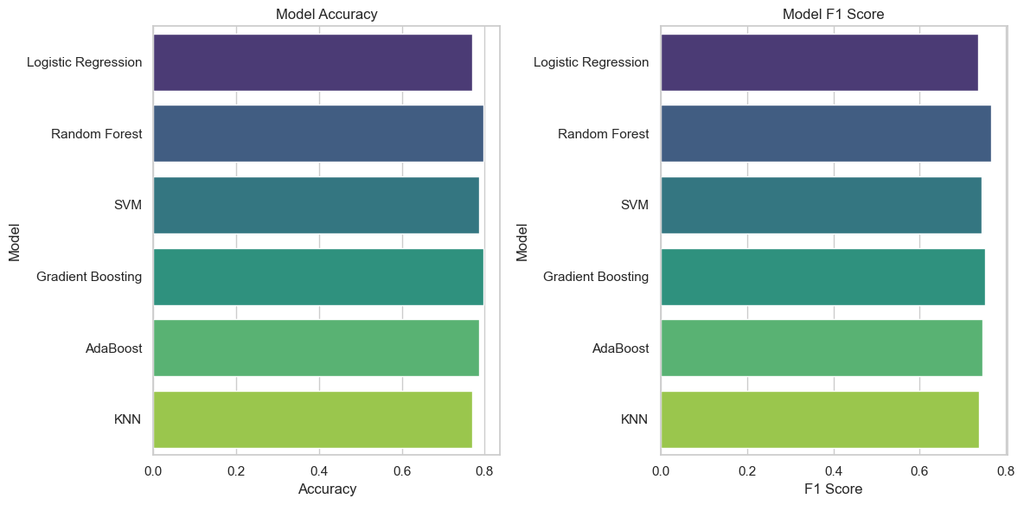

```python
# Define metrics for Logistic Regression
accuracy_lr = accuracy_score(y_test, y_pred_lr)
f1_lr = f1_score(y_test, y_pred_lr)

# Define metrics for Random Forest
accuracy_rf = accuracy_score(y_test, y_pred_rf)
f1_rf = f1_score(y_test, y_pred_rf)

# Define metrics for SVM
accuracy_svc = accuracy_score(y_test, y_pred_svc)
f1_svc = f1_score(y_test, y_pred_svc)

# Define metrics for Gradient Boosting
accuracy_gb = accuracy_score(y_test, y_pred_gb)
f1_gb = f1_score(y_test, y_pred_gb)

# Define metrics for AdaBoost
accuracy_ada = accuracy_score(y_test, y_pred_ada)
f1_ada = f1_score(y_test, y_pred_ada)

# Define metrics for KNN
accuracy_knn = accuracy_score(y_test, y_pred_knn)
f1_knn = f1_score(y_test, y_pred_knn)

# Define a dictionary to store performance metrics
performance_metrics = {
    'Model': ['Logistic Regression', 'Random Forest', 'SVM', 'Gradient Boosting', 'AdaBoost', 'KNN'],
    'Accuracy': [accuracy_lr, accuracy_rf, accuracy_svc, accuracy_gb, accuracy_ada, accuracy_knn],
    'F1 Score': [f1_lr, f1_rf, f1_svc, f1_gb, f1_ada, f1_knn]
}

# Create a DataFrame from the dictionary
performance_df = pd.DataFrame(performance_metrics)

# Print the DataFrame
print(performance_df)

# Plot the performance metrics
plt.figure(figsize=(12, 6))

# Plot accuracy
plt.subplot(1, 2, 1)
sns.barplot(x='Accuracy', y='Model', data=performance_df, palette='viridis')
plt.title('Model Accuracy')

# Plot F1 Score
plt.subplot(1, 2, 2)
sns.barplot(x='F1 Score', y='Model', data=performance_df, palette='viridis')
plt.title('Model F1 Score')

plt.tight_layout()
plt.show()
```

```python
import pandas as pd

# Define metrics for each model
performance_metrics = {
    'Model': ['Logistic Regression', 'Random Forest', 'SVM', 'Gradient Boosting', 'AdaBoost', 'KNN'],
    'Accuracy': [accuracy_lr, accuracy_rf, accuracy_svc, accuracy_gb, accuracy_ada, accuracy_knn],
    'F1 Score': [f1_lr, f1_rf, f1_svc, f1_gb, f1_ada, f1_knn]
}

# Create a DataFrame from the dictionary
performance_df = pd.DataFrame(performance_metrics)

# Print the DataFrame
print("Model Performance Summary:")
print(performance_df)

# Determine the best model based on Accuracy
best_model_accuracy = performance_df.loc[performance_df['Accuracy'].idxmax()]
print("\nBest Model Based on Accuracy:")
print(best_model_accuracy)

# Determine the best model based on F1 Score
best_model_f1 = performance_df.loc[performance_df['F1 Score'].idxmax()]
print("\nBest Model Based on F1 Score:")
print(best_model_f1)
```

```
Model Performance Summary:
                 Model  Accuracy  F1 Score
0  Logistic Regression  0.770992  0.734513
1        Random Forest  0.797710  0.764444
2                  SVM  0.786260  0.743119
3    Gradient Boosting  0.797710  0.751174
4             AdaBoost  0.786260  0.745455
5                  KNN  0.770992  0.736842

Best Model Based on Accuracy:
Model       Random Forest
Accuracy          0.79771
F1 Score         0.764444
Name: 1, dtype: object

Best Model Based on F1 Score:
Model       Random Forest
Accuracy          0.79771
F1 Score         0.764444
Name: 1, dtype: object
```

# Binary Classification Problem Summary

## Project Objective

The goal of this project was to build a predictive model to determine which passengers were more likely to survive the Titanic disaster, based on passenger data such as name, age, gender, and socio-economic class.

## Data Overview

The dataset used for this challenge is a commonly employed dataset for classification problems, where the target variable is survived:

```
1. 1 indicates the passenger survived.
2. 0 indicates the passenger did not survive.
```

## Key steps in the analysis included:

1. Data Exploration
2. Examined basic statistics and the distribution of the survived variable.
3. Visualized the class distribution and survival rates by various features such as gender and passenger class.
4. Data Preprocessing
5. Handling Missing Values: Filled missing values in age and embarked, and dropped columns with excessive missing values.
6. Feature Engineering: Created new features like family_size and removed irrelevant columns.
7. Categorical Encoding: Converted categorical variables into numeric using one-hot encoding and label mapping.
8. Normalization: Standardized the age and fare columns.
9. Data Splitting
10. Split the data into training and testing sets.
11. Balancing the Data
12. Applied SMOTE to address class imbalance in the training set.
13. Exploratory Data Analysis (EDA)
14. Analyzed the distribution of passenger ages and survival rates by gender and passenger class.
15. Evaluated feature correlations with survival.
16. Model Training and Evaluation
17. Models Implemented: Logistic Regression Random Forest Classifier Support Vector Machine (SVM) Gradient Boosting Classifier AdaBoost Classifier K-Nearest Neighbors (KNN)
18. Hyperparameter Tuning: Used GridSearchCV to optimize hyperparameters for Random Forest and SVM.
19. Performance Metrics: Evaluated models using Accuracy and F1 Score. ### Results **Model Performance Summary:**

[output not shown]

**Best Model Based on Accuracy: Random Forest**

**Best Model Based on F1 Score: Random Forest**